# Simulation Study: Design & Data Generation

Joon-Ho Lee (joonho@berkeley.edu)

February 6, 2020

# 1 Bayes deconvolution problem

The basic two-stage sampling model that we focus on in this document is

$$y_{k}|\theta_{k} \sim N(\theta_{k}, \sigma_{k}^2),$$
$$\theta_{k}|G \overset{\text{iid}}{\sim} G,$$
$$G \sim f(G),$$

where $k = 1, ..., K$, $K$ is the number of second-stage units under analysis, $\sigma_{k}^2$ is the variance of the observed data, $y_{k}$, and $f(G)$ is the prior distribution of $G$. The site-specific parameters of interest, $\theta_{k} (k = 1, ..., K)$ comes from the population distribution, $G$. The observations, $y_{k} (k = 1, ..., K)$ comes from a Gaussian sampling distribution that depends on the $\theta_{k}$’s. An example of such a scenario is when student outcomes are observed within schools.

What if we don’t know about the prior density $G$? Empirical or full Bayes methods attempt to estimate $G$ from the observed sample $Y = (y_1, y_2, ..., y_K)$. In the normal model, the marginal density of $Y$ is the *convolution* of $G$ with a standard $N(0, 1)$ density. The empirical or full Bayes task is one of *deconvolution*: using the observed sample $Y$ from the marginal density to estimate $G$. The *Bayes deconvolution problem* is a general name for estimating $G$ given a random sample from the marginal density of $Y$ (Efron 2016).

# 2 Design[^1]

We evaluate estimators under the basic two-stage model. The distribution $G$ is assumed to be unknown and is estimated using either empirical Bayes or fully hierarchical Bayesian approaches.

The data-generating scenarios are varied as follows:

```r
### Define a function to generate sigma vector
gen_sigma <- function(n, rgt, rsr){

  # Set maximum and minimum within-site variances
  sigma2max <- rgt*rsr
  sigma2min <- sigma2max/(rsr^2)

  # Generate within-site variances for K sites
  sigma2 <- exp(seq(from = log(sigma2min), to = log(sigma2max), length = n))

  return(sigma2)
}

### Define a function to calculate geometric mean
geom_mean <- function(x){exp(mean(log(x)))}
```

The estimated sample geometric mean is equal to `rgt`:

```r
### Get example geometric means
vec_rgt <- c(0.1, 0.33, 1.0)
list_emp <- list()

for (i in seq_along(vec_rgt)){
  list_emp[[i]] <- gen_sigma(n = 50, rgt = vec_rgt[i], rsr = 5)
}

unlist(lapply(list_emp, geom_mean))
```

```
## [1] 0.10 0.33 1.00
```

Between-site variances ($\text{var}(\theta_k))$) are set to 1 in all data-generating models. Within-site variances are generated depending upon `rgt` and `rsr` values. The intraclass correlations (ICCs) for different `rsr` values are

```r
### Get ranges of ICCs
vec_rsr <- c(1, 5, 10)
list_emp <- list()

for (i in seq_along(vec_rgt)){
  list_emp[[i]] <- range(1/(gen_sigma(n = 50, rgt = 1, rsr = vec_rsr[i]) + 1))
}

names(list_emp) <- paste0("rsr = ", vec_rsr)
lapply(list_emp, round, 2)
```

```
## $`rsr = 1`
## [1] 0.5 0.5
##
## $`rsr = 5`
## [1] 0.17 0.83
##
## $`rsr = 10`
## [1] 0.09 0.91
```

4. The true population distribution of $G$
   - $G$ will be simulated to either follow
     1. a Gaussian distribution with mean 0 and variance 1
     2. a $T_5$ distribution normalized to have mean 0 and variance 1
     3. a mixture $0.8 \cdot \mathrm{N}(0, 1) + 0.2 \cdot \mathrm{N}(4, 1)$ that is normalized to have mean 0 and variance 1.

Our simulation study is based on the following data-generating and data analysis scenario.

```r
### Set seed
set.seed(10101)

### Generate a table of the simulation parameters
tbl_param <- expand.grid(truth = c("Gaussian", "Mdp", "Tdist"),
                         assumed = c("Gaussian", "Mdp", "Tdist", "NPML", "SBR"),
                         rgt = c(0.1, 0.33, 1, 10),
                         rsr = c(1, 5, 10),
                         n = c(25, 50, 100, 200),
                         df = 5)

### Reorder the table & add a variable
tbl_param <- tbl_param %>%
  arrange(n, rgt, rsr, truth, assumed)

### Add a concatenated design indicator
simulparam <- tbl_param %>%
  unite(fname, truth, assumed, rgt, rsr, n, sep = "_") %>%
  dplyr::select(-df) %>%
  cbind.data.frame(tbl_param) %>%
  select(truth:df, fname)

head(simulparam, 10)
```

```
##       truth  assumed rgt rsr  n df                      fname
## 1  Gaussian Gaussian 0.1   1 25  5 Gaussian_Gaussian_0.1_1_25
## 2  Gaussian      Mdp 0.1   1 25  5      Gaussian_Mdp_0.1_1_25
## 3  Gaussian    Tdist 0.1   1 25  5    Gaussian_Tdist_0.1_1_25
## 4  Gaussian     NPML 0.1   1 25  5     Gaussian_NPML_0.1_1_25
## 5  Gaussian      SBR 0.1   1 25  5      Gaussian_SBR_0.1_1_25
## 6       Mdp Gaussian 0.1   1 25  5      Mdp_Gaussian_0.1_1_25
## 7       Mdp      Mdp 0.1   1 25  5           Mdp_Mdp_0.1_1_25
## 8       Mdp    Tdist 0.1   1 25  5         Mdp_Tdist_0.1_1_25
## 9       Mdp     NPML 0.1   1 25  5          Mdp_NPML_0.1_1_25
## 10      Mdp      SBR 0.1   1 25  5           Mdp_SBR_0.1_1_25
```

# 3 Define functions to generate simulated data

## 3.1 A Gaussian distribution

$G$ will be simulated to follow a Gaussian distribution with mean 0 and variance 1. We first set our simulation parameters to reflect a range of data informativeness and heterogeneity among sites with respect to variance.

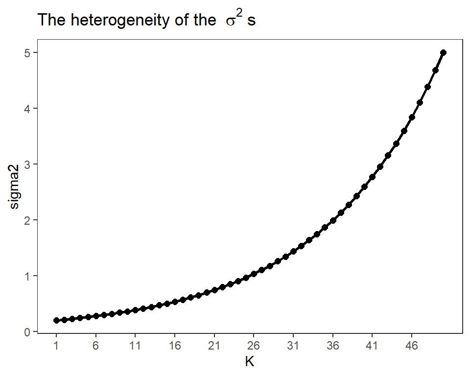

```r
### Example settings
n <- 50; rgt <- 1; rsr <- 5

### Set maximum and minimum within-site variances
sigma2max <- rgt*rsr
sigma2min <- sigma2max/(rsr^2)

### Generate within-site variances (sds) for K sites
sigma2 <- exp(seq(from = log(sigma2min), to = log(sigma2max), length = n))
sd <- sqrt(sigma2)

### Plot within-site variances
df_temp <- tibble(sigma2, sd) %>%
  mutate(K = 1:n())

ggplot(data = df_temp, aes(x = K, y = sigma2)) +
  geom_point(size = 2.0) + geom_path(size = 1.0) +
  scale_x_continuous(breaks = seq(1, n, by = 5)) +
  labs(title = bquote("The heterogeneity of the " ~ sigma^2 ~"s")) +
  theme_preset
```

The **R** function that follows simulates a dataset conforming to the Gaussian model.

```r
### Define a function to generate Gaussian random draws
GenerateGaussian <- function(n, rgt, rsr) {

  ### Generate within-site variances (sds) for K sites
  sigma2max <- rgt*rsr
  sigma2min <- sigma2max/(rsr^2)
  sigma2 = exp(seq(from = log(sigma2min), to = log(sigma2max), length = n))
  sd = sqrt(sigma2)

  ### Set mean and SD of standard normal distribution
  mn <- 0; tau <- sqrt(1)

  ### Generate data (Note the difference between theta and Y)
  data_obj <- list()
  data_obj$theta <- rnorm(n, mn, tau)        # site means
  data_obj$Y <- rnorm(n, data_obj$theta, sd) # within-site outcome (only one per site)
  data_obj$sigma2 <- sigma2                  # site SDs
  return(data_obj)
}

### Generate sample draws from the Gaussian model
df_G <- GenerateGaussian(n = 50, rgt = 1, rsr = 5) %>%
  data.frame() %>%
  rownames_to_column("K") %>%
  mutate_at(.vars = c("K"), .funs = as.numeric)

head(df_G)
```

```
##   K      theta            Y    sigma2
## 1 1 -0.8767670 -1.435719666 0.2000000
## 2 2 -0.7463894 -1.178510709 0.2135794
## 3 3  1.3759148  1.857748043 0.2280808
## 4 4  0.2375820  0.007323866 0.2435668
## 5 5  0.1086275  0.103486375 0.2601043
## 6 6  1.2027213  1.214734039 0.2777646
```

Next, we compare the observed estimates ($Y_k$) to the true distribution of $\theta_k$.

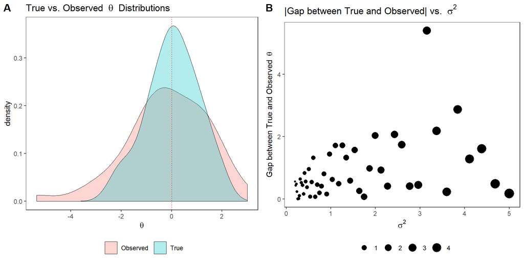

```r
### Define a function to generate plot
plot_compare_true_obs <- function(df_G){

  # Compare the true distribution (theta) to the observed data (Y)
  df_plot <- df_G %>%
    select(theta, Y) %>%
    rename(True = theta, Observed = Y) %>%
    gather(key = variable, value = value)

  p1 <- ggplot(data = df_plot, aes(x = value, group = variable, fill = variable)) +
      geom_density(position = "identity", size = 0.1, alpha = 0.3) +
      geom_vline(aes(xintercept = 0), size = 0.3, color = "red", linetype = "dashed") +
      labs(title = bquote("True vs. Observed " ~ theta ~" Distributions"),
           x = expression(theta)) + theme_preset

  # Compare point estimates by sigma_k (cleveland dot chart)
  p2 <- ggplot(data = df_G %>% mutate(gap = abs(Y - theta)), aes(x = sigma2, y = gap)) +
      geom_point(aes(size = sigma2)) +
    labs(title = bquote("|Gap between True and Observed| vs. " ~ sigma^2),
         y = bquote("Gap between True and Observed " ~ theta),
         x = expression(sigma^2)) + theme_preset

  # Combine the two plots
  p_grid <- plot_grid(p1, p2, labels = "AUTO")
  return(p_grid)
}

plot_compare_true_obs(df_G)
```

The empirical distribution function (EDF) of the observed $y_k$ is overdispersed due to the uncertainty of the observed data, $\sigma_k^2$. The discrepancy between true and observed $\theta_k$s tends to be larger for the sites with larger $\sigma_k^2$.

## 3.2 A T-distribution with $df = 5$

$G$ will be simulated to follow a $T$-distribution with $df = 5$ normalized to have mean 0 and variance 1. The t-distribution is symmetric and bell-shaped, like the normal distribution, but has heavier tails, meaning that it is more prone to producing values that fall far from its mean.

[figure not shown]

The **R** function that follows simulates a dataset conforming to the $T$ model.

```r
### Define a function to generate random draws from T-distribution with df = 5 (nu)
GenerateT <- function(n, rgt, rsr, nu) {

  ### Generate within-site variances (sds) for K sites
  sigma2max <- rgt*rsr
  sigma2min <- sigma2max/(rsr^2)
  sigma2 <- exp(seq(from = log(sigma2min), to = log(sigma2max), length = n))
  sd <- sqrt(sigma2)

  ## Mean of T-distribution
  mn <- 0

  ## Generate data object
  data_obj <- list()
  data_obj$theta <- rt(n, nu)*sqrt((nu - 2)/nu)
  data_obj$Y <- rnorm(n, data_obj$theta, sd)
  data_obj$sigma2 <- sigma2
  return(data_obj)
}

### Generate sample draws from the T model
df_G <- GenerateT(n = 50, rgt = 1, rsr = 5, nu = 5) %>%
  data.frame() %>%
  rownames_to_column("K") %>%
  mutate_at(.vars = c("K"), .funs = as.numeric)

head(df_G)
```

```
##   K       theta           Y    sigma2
## 1 1 -1.68485019 -1.93926765 0.2000000
## 2 2 -0.57498057 -0.79002799 0.2135794
## 3 3 -0.08203628 -0.09610355 0.2280808
## 4 4  0.58672415  1.07945321 0.2435668
## 5 5 -0.50972658 -1.29247015 0.2601043
## 6 6  0.62529546 -0.02297688 0.2777646
```

Next, we compare the observed estimates ($Y_k$) to the true distribution of $\theta_k$.

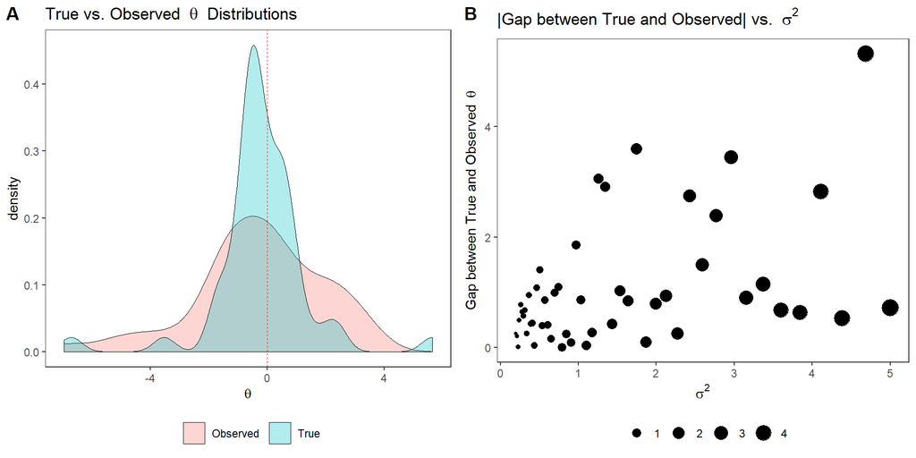

```r
plot_compare_true_obs(df_G)
```

## 3.3 A mixture of two Gaussian homoscedastic components

$G$ will be simulated to follow a mixture $0.8N(0, 1) + 0.2N(4, 1)$ that is normalized to have mean 0 and variance 1.

In general, a mixture model assumes the data are generated by the following process: first we sample $z$, and then we sample the observables $\mathrm{y}$ from a distribution which depends on $z$, i.e,

$$p(z, \mathrm{y}) = p(z)p(\mathrm{y}|z).$$

In mixture models, $p(z)$ is always a multinomial distribution. $p(\mathrm{y}|x)$ can take a variety of parametric forms, but we assume that it is a Gaussian distribution. We refer to such a model as a **mixture of Gaussians**. It has the following generative process:

1. With probability of 0.8, choose the first component ($N(0, 1)$), otherwise choose the second component ($N(4, 1)$).
2. If we chose the first component, then sample $y$ from a Gaussian with mean 0 and standard deviation 1.
3. If we chose the second component, then sample $y$ from a Gaussian with mean 4 and standard deviation 1.

In general, we can compute the probability density function (PDF) over $\mathrm{y}$ by marginalizing out, or summing out, $z$:

$$\begin{array}{rcl}
p(\mathrm{y}) &=& \displaystyle\sum_{z}{p(z)p(\mathrm{y}|z)}
\\ &=& \displaystyle\sum_{k = 1}^{K}{\mathrm{Pr}(z=k)p(\mathrm{y}|z = k)}.
\end{array}$$

The **R** function that follows simulates a dataset conforming to the mixture model. We first generate a random vector indicating components.

```r
### Set parameters
tailp <- c(0.05, 0.1, 0.25, 0.75, 0.9, 0.95)  # tail probabilities
delta <- 4    # distance between two mixtures
ups <- 1      # want components to have equal variance
eps <- 0.2    # mixing proportion (smaller side)

### Generate a random vector indicating components
ind <- runif(20000) < (1 - eps)
prop.table(table(ind))
```

```
## ind
##  FALSE   TRUE
## 0.2002 0.7998
```

Then we draw samples from the PDF which is a convex combinatino or weighted avearage of the PDFs of the component distributions. Note, however, that we want the $\mathrm{y}$ to be normalized to have mean 0 and variance 1. We thus first define a normalizing factor `a`, and then generate true PDF of $y$s from the mixture distribution with 20,000 simulated draws.

```r
### Define a normalizing factor `a`
a <- sqrt((1 - eps) + eps*ups^2 + eps*(1 - eps)*delta^2)
a
```

```
## [1] 1.886796
```

```r
### Get true PDF of thetas from mixture
quant <- ind*rnorm(20000, -eps*delta/a, sqrt(1/a^2)) +
  (1 - ind)*rnorm(20000, (1 - eps)*delta/a, sqrt(ups^2/a^2))

### Get true tail quantiles
mdppriquan <- quantile(quant, tailp)

### Check mean, SD, and quantiles of the true PDF
c(mean(quant), sd(quant))
```

```
## [1] -0.002797227  1.000072029
```

```r
mdppriquan
```

```
##         5%        10%        25%        75%        90%        95%
## -1.2482341 -1.0428611 -0.6842158  0.3607082  1.6994388  2.0639198
```

The `GenerateMdp` function can be defined as follows.

```r
### Define a function to generate random draws from the mixture distribution
GenerateMdp <- function(n, rgt, rsr){

  ### Set parameters
  data_obj <- list()
  data_obj <- NULL
  delta <- 4    # distance between two mixtures
  ups <- 1      # want components to have equal variance
  eps <- 0.2    # mixing proportion (smaller side)

  ### Define a normalizing factor `a`
  a <- sqrt((1 - eps) + eps*ups^2 + eps*(1 - eps)*delta^2)

  ### Simulate a mixture of 2 normals with mean 0 and var 1  with this parameterization
  ind <- runif(n) < (1 - eps)
  data_obj$theta <- ind*rnorm(n, -eps*delta/a, sqrt(1/a^2)) +
    (1 - ind)*rnorm(n, (1 - eps)*delta/a, sqrt(ups^2/a^2))

  ### Simulate true distribution for quantiles etc.
  ind <- runif(n) < (1 - eps)
  data_obj$theta <- ind*rnorm(n, -eps*delta/a, sqrt(1/a^2)) +
    (1 - ind)*rnorm(n, (1 - eps)*delta/a, sqrt(ups^2/a^2))
  tailp <- c(0.05, 0.1, 0.25, 0.75, 0.9, 0.95)

  ### Generate within-site variances (sds) for K sites
  sigma2max <- rgt*rsr
  sigma2min <- sigma2max/(rsr^2)
  sigma2 <- exp(seq(from = log(sigma2min), to = log(sigma2max), length = n))
  sd <- sqrt(sigma2)

  ### Generate data object (observed Y)
  data_obj$Y <- rnorm(n, data_obj$theta, sd)
  data_obj$sigma2 <- sigma2
  data_obj$priquan <- mdppriquan
  return(data_obj)
}

### Generate sample draws from the mixture model
df_G <- GenerateMdp(n = 50, rgt = 1, rsr = 5)[c(1:3)] %>%
  data.frame() %>%
  rownames_to_column("K") %>%
  mutate_at(.vars = c("K"), .funs = as.numeric)

head(df_G)
```

```
##   K      theta          Y    sigma2
## 1 1  0.1456964  0.3473876 0.2000000
## 2 2 -0.7088267 -0.3891349 0.2135794
## 3 3  2.5954849  2.0283340 0.2280808
## 4 4 -0.3621723 -0.1550452 0.2435668
## 5 5 -1.2505259 -1.2228465 0.2601043
## 6 6 -0.4169629 -0.5921068 0.2777646
```

Next, we compare the observed estimates ($Y_k$) to the true distribution of $\theta_k$.

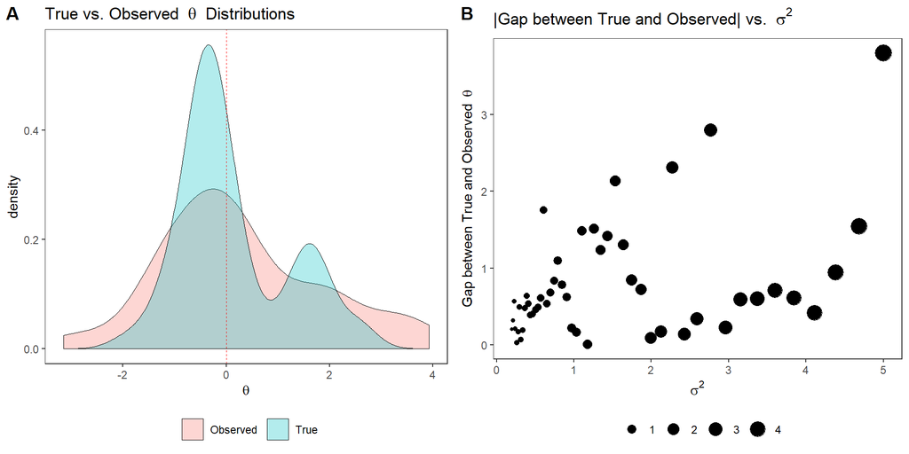

```r
plot_compare_true_obs(df_G)
```

## 3.4 A mixture of two T-distributions

$G$ will be simulated to follow a mixture of two T-distribution. We generate 75% of the sample from a $T(df = 8)$ and 25% from a $T(df = 50)$.

```r
### Define a function to generate random draws from a mixture of two Ts
GenerateSmix <- function(n, rgt, rsr) {

  ### Generate within-site variances (sds) for K sites
  sigma2max <- rgt*rsr
  sigma2min <- sigma2max/(rsr^2)
  sigma2 <- exp(seq(from = log(sigma2min), to = log(sigma2max), length = n))
  sd <- sqrt(sigma2)

  ### Generate data object
  data_obj <- list()
  nnorm <- floor(0.25*n)
  data_obj$theta <- rt(n, 8)
  data_obj$theta[1:nnorm] <- rt(nnorm, 50)  # replace the floor samples
  data_obj$Y <- rnorm(n, data_obj$theta, sd)
  data_obj$sigma2 <- sigma2
  return(data_obj)
}

### Generate sample draws from the mixture model
df_G <- GenerateSmix(n = 50, rgt = 1, rsr = 5) %>%
  data.frame() %>%
  rownames_to_column("K") %>%
  mutate_at(.vars = c("K"), .funs = as.numeric)

head(df_G)
```

```
##   K      theta            Y    sigma2
## 1 1  0.6241019  0.186244826 0.2000000
## 2 2 -0.2158693  0.002623487 0.2135794
## 3 3  1.3140652  1.013270120 0.2280808
## 4 4 -0.1109707  0.086671058 0.2435668
## 5 5 -0.9057100 -1.194864717 0.2601043
## 6 6  0.3119526 -0.262373052 0.2777646
```

Note, however, that the true $\theta$ distribution is not normalized to have mean 0 and variance 1.

```r
### Mean and SD of the T-mixture
c(mean(df_G$theta), sd(df_G$theta))
```

```
## [1] -0.04318415  0.99403909
```

Next, we compare the observed estimates ($Y_k$) to the true distribution of $\theta_k$.

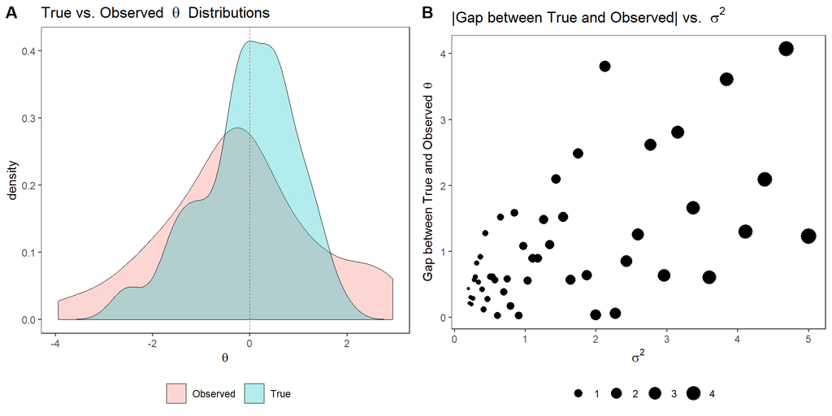

```r
plot_compare_true_obs(df_G)
```

# References

Efron, Bradley. 2016. “Empirical Bayes Deconvolution Estimates.” *Biometrika* 103 (1): 1–20.

Paddock, Susan M, Greg Ridgeway, Rongheng Lin, and Thomas A Louis. 2006. “Flexible Distributions for Triple-Goal Estimates in Two-Stage Hierarchical Models.” *Computational Statistics & Data Analysis* 50 (11): 3243–62.

[^1]: This largely replicates the design of Paddock et al. (2006)